# CoCoA Permutation-Based Differential Analysis

2026-02-12

## Introduction

**CoCoA** (Confounder-adjusted Co-expression Analysis) provides differential expression analysis that accounts for confounding in single-cell data. This vignette demonstrates:

1. Simulating single-cell data with confounded exposure assignment
2. Running CoCoA’s permutation-based differential testing
3. Comparing results with a naive pseudobulk Wilcoxon rank-sum test

The key advantage of CoCoA’s permutation approach is proper calibration under confounding: shuffling exposure labels under the null preserves the confounding structure, yielding valid p-values even when confounders correlate with both exposure and gene expression.

## Setup

```r
temp_dir <- "temp_cocoa_diff_vignette"
if (!dir.exists(temp_dir)) dir.create(temp_dir)
```

## Getting Help

```bash
cocoa diff --help
```

```
## Differential expression analysis on pseudobulk data
## while adjusting confounding effects by cross-condition
## or cross-exposure/treatment matching (Park & Kellis, 2020).
##
##
##
## Usage: cocoa diff [OPTIONS] --indv-files <INDV_FILES> --exposure-assignment-file <EXPOSURE_ASSIGNMENT_FILE> --out <OUT> <DATA_FILES>...
##
## Arguments:
##   <DATA_FILES>...
##           Data files of either `.zarr` or `.h5` format.
##           All the formats in the given list should be identical.
##           You can convert `.mtx` to `.zarr` or `.h5` using the `data-beans`
##
## Options:
##   -i, --indv-files <INDV_FILES>
##           Individual membership files (comma-separated file names).
##           Each line in each file can specify:
##           * just  individual ID or
##           * (1) Cell and (2) individual ID pair.
##
##   -e, --exposure-assignment-file <EXPOSURE_ASSIGNMENT_FILE>
##           Each line corresponds to:
##           (1) individual name and (2) exposure name.
##
##   -t, --topic-assignment-files <TOPIC_ASSIGNMENT_FILES>
##           Latent topic assignment files (comma-separated file names).
##           Each line in each file can specify:
##           * just topic name or
##           * (1) cell and (2) topic name pair.
##
##   -r, --topic-proportion-files <TOPIC_PROPORTION_FILES>
##           Latent topic proportion files (comma-separated file names).
##           Each file contains a full `cell x topic` matrix.
##
##       --topic-proportion-value <TOPIC_PROPORTION_VALUE>
##           Specify if the topic proportion matrix is of probability type.
##           Default is `logit`-valued.
##
##           [default: logit]
```

[output cut: 42 more lines]

```
##
##       --preload-data
##           Preload all the columns data.
##
##       --confounder-file <CONFOUNDER_FILE>
##           Provide a known individual-level confounder matrix V instead of
##           discovering confounders by random projection. The file should be
##           a tab-delimited matrix (n_indv x n_covar) in .tsv.gz format.
##           Rows correspond to individuals 0, 1, 2, ... in order.
##
##   -v, --verbose
##           Increase output verbosity.
##
##   -h, --help
##           Print help (see a summary with '-h')
```

## Step 1: Simulate Data

We simulate single-cell count data with:

- 200 genes (10 causal, differentially expressed between exposure groups)
- ~5000 cells across 20 individuals (10 per exposure group)
- Strong confounding: covariates explain 80% of variance in both exposure and expression
- Moderate effect size (1.0 standard deviations)

```bash
[ -d "temp_cocoa_diff_vignette/sim.zarr" ] && echo "Skipping: sim.zarr exists" && exit 0
cocoa simulate-one -r 200 -c 5000 -a 10 \
  --n-samples-per-exposure 10 \
  --effect-size 1.0 \
  --pve-covar-exposure 0.8 \
  --pve-covar-gene 0.8 \
  -o temp_cocoa_diff_vignette/sim \
  -v
```

```
## [2026-02-13T00:23:20Z INFO  cocoa::run_sim_one_type] Simulating underlying individual-level data...
## [2026-02-13T00:23:20Z INFO  cocoa::run_sim_one_type] Populating triplets...
## [2026-02-13T00:23:20Z INFO  cocoa::run_sim_one_type] Total 5073 cells of 200 genes
## [2026-02-13T00:23:20Z INFO  cocoa::run_sim_one_type] Successfully simulated
## [2026-02-13T00:23:20Z INFO  cocoa::run_sim_one_type] registering triplets ...
## [2026-02-13T00:23:20Z INFO  cocoa::run_sim_one_type] done
```

The simulation outputs:

- `sim.zarr` – sparse single-cell count matrix (genes x cells)
- `sim.samples.gz` – cell-to-individual assignment (one line per cell)
- `sim.exposures.gz` – individual-to-exposure mapping
- `sim.causal.gz` – ground-truth causal gene indices and their exposure category

## Step 2: Run CoCoA Differential Analysis with Permutations

CoCoA builds a KNN graph within each exposure condition, estimates gene-level effects, then permutes exposure labels to build a null distribution. With 50 permutations, we get empirical z-scores and p-values.

```bash
[ -f "temp_cocoa_diff_vignette/cocoa_result.perm.tsv.gz" ] && echo "Skipping: cocoa_result exists" && exit 0
cocoa diff temp_cocoa_diff_vignette/sim.zarr \
  -i temp_cocoa_diff_vignette/sim.samples.gz \
  -e temp_cocoa_diff_vignette/sim.exposures.gz \
  --n-permutations 50 \
  --permutation-seed 42 \
  -o temp_cocoa_diff_vignette/cocoa_result \
  -v
```

[output not shown]

[output cut: 255 more lines]

[output not shown]

## Step 3: Load CoCoA Results

```r
library(dplyr)
library(tidyr)
library(ggplot2)
library(arrow)

# Read permutation test results (gene, contrast, z_score, pvalue)
cocoa_perm <- read.delim(
  gzfile("temp_cocoa_diff_vignette/cocoa_result.perm.tsv.gz"),
  header = TRUE
)
head(cocoa_perm)
```

```
##   gene   contrast    z_score    pvalue
## 1    0  0.7132621  1.5686964 0.1167187
## 2    1 -0.5410845 -1.1746109 0.2401504
## 3    2  0.2879108  0.6908991 0.4896290
## 4    3  0.5780994  1.2759746 0.2019645
## 5    4 -0.6279763 -1.1693707 0.2422543
## 6    5 -0.3870887 -0.7877747 0.4308285
```

```r
# Read ground-truth causal genes (gene_idx, exposure_category)
causal <- read.delim(
  gzfile("temp_cocoa_diff_vignette/sim.causal.gz"),
  header = FALSE,
  col.names = c("gene_idx", "exposure_cat")
)
causal$gene <- as.character(causal$gene_idx)
cat("Causal genes:", sort(causal$gene_idx), "\n")
```

```
## Causal genes: 32 92 119 127 132 142 160 163 164 173
```

```r
# Flag causal genes in CoCoA results
cocoa_perm$causal <- cocoa_perm$gene %in% causal$gene

# Top hits by |z-score|
cocoa_perm %>%
  arrange(desc(abs(z_score))) %>%
  head(20)
```

```
##    gene   contrast   z_score      pvalue causal
## 1    32  1.6911275  3.096564 0.001957776   TRUE
## 2   173 -1.6627479 -2.981062 0.002872511   TRUE
## 3   142 -1.5748663 -2.963028 0.003046289   TRUE
## 4    70 -1.2012502 -2.221647 0.026307186  FALSE
## 5    73  0.9856340  2.035999 0.041750472  FALSE
## 6   137 -0.7005804 -1.999179 0.045588978  FALSE
## 7   150  0.7320242  1.942596 0.052064937  FALSE
## 8    94  0.6542761  1.933995 0.053113730  FALSE
## 9    80 -0.8966700 -1.922184 0.054582626  FALSE
## 10   16 -0.5760190 -1.892729 0.058393847  FALSE
## 11  112  0.7681194  1.853858 0.063759460  FALSE
## 12  148 -0.8822664 -1.819745 0.068797894  FALSE
## 13   90  0.8667659  1.802429 0.071477940  FALSE
## 14   37 -0.8918424 -1.783521 0.074501520  FALSE
## 15   89  0.7956671  1.777640 0.075462945  FALSE
## 16   99  0.8363116  1.758913 0.078592260  FALSE
## 17  107  0.7195561  1.757847 0.078773620  FALSE
## 18   97 -0.6331784 -1.737904 0.082227804  FALSE
## 19   85  0.8048498  1.724356 0.084643565  FALSE
## 20  188 -0.8318300 -1.720538 0.085334780  FALSE
```

## Step 4: Pseudobulk Aggregation

To run a naive pseudobulk test, we first aggregate single-cell counts to individual-level means using `data-beans stat`. This requires a membership file mapping each cell to its individual.

```bash
[ -f "temp_cocoa_diff_vignette/cell_names.gz" ] && echo "Skipping: cell_names exists" && exit 0
data-beans column-names temp_cocoa_diff_vignette/sim.zarr \
  -o temp_cocoa_diff_vignette/cell_names.gz
```

```r
# Build membership file: cell name -> individual ID
cell_names <- readLines(gzfile("temp_cocoa_diff_vignette/cell_names.gz"))
samples <- readLines(gzfile("temp_cocoa_diff_vignette/sim.samples.gz"))

n <- min(length(cell_names), length(samples))
cat("Cells:", length(cell_names), "  Sample assignments:", length(samples),
    "  Using:", n, "\n")
```

```
## Cells: 5000   Sample assignments: 5073   Using: 5000
```

```r
membership <- data.frame(row = cell_names[1:n], group = samples[1:n])
write.table(membership, "temp_cocoa_diff_vignette/membership.tsv",
            sep = "\t", row.names = FALSE, quote = FALSE)
```

```bash
[ -f "temp_cocoa_diff_vignette/pseudobulk.parquet" ] && echo "Skipping: pseudobulk exists" && exit 0
data-beans stat \
  temp_cocoa_diff_vignette/sim.zarr \
  -s row \
  -g temp_cocoa_diff_vignette/membership.tsv \
  -o temp_cocoa_diff_vignette/pseudobulk.parquet
```

```
## [2026-02-13T00:24:56Z INFO  data_beans::sparse_io_vector] Checking row names...
## [2026-02-13T00:24:56Z INFO  data_beans::sparse_io_vector] Added 5073 columns
## [2026-02-13T00:24:56Z INFO  matrix_util::membership] Loaded 5001 entries from temp_cocoa_diff_vignette/membership.tsv
## [2026-02-13T00:24:56Z INFO  data_beans::handlers::analysis] Column matching: 5000 exact + 0 base_key + 0 prefix = 5000/5000 matched
## [2026-02-13T00:24:56Z INFO  data_beans::handlers::analysis] Will collect stats for 21 groups: ["0", "1", "10", "11", "12", "13", "14", "15", "16", "17", "18", "19", "2", "3", "4", "5", "6", "7", "8", "9", "group"]
## [2026-02-13T00:24:56Z INFO  data_beans::handlers::analysis] Collected 20 group stats: ["19", "10", "6", "14", "13", "3", "8", "18", "17", "7", "12", "0", "9", "16", "4", "11", "1", "15", "5", "2"]
## [2026-02-13T00:24:56Z INFO  data_beans::handlers::analysis] writing out: temp_cocoa_diff_vignette/pseudobulk.parquet
```

## Step 5: Wilcoxon Rank-Sum Test

We run a naive Wilcoxon rank-sum test on the pseudobulk means, comparing individuals in the two exposure groups gene by gene.

```r
# Read pseudobulk statistics (name, group, nnz, tot, mu, sig)
pseudobulk <- read_parquet("temp_cocoa_diff_vignette/pseudobulk.parquet")
head(pseudobulk)
```

```
## # A tibble: 6 × 6
##   name  group   nnz   tot    mu   sig
##   <chr> <chr> <dbl> <dbl> <dbl> <dbl>
## 1 0     19       27    34 0.192 0.484
## 2 1     19      160  1630 9.21  9.64
## 3 2     19       22    24 0.136 0.374
## 4 3     19       40    45 0.254 0.507
## 5 4     19      154  1172 6.62  7.07
## 6 5     19      143   711 4.02  4.55
```

```r
# Read exposure assignments (individual -> exposure group)
exposures <- read.delim(
  gzfile("temp_cocoa_diff_vignette/sim.exposures.gz"),
  header = FALSE,
  col.names = c("indv", "exposure")
)
exposure_map <- setNames(as.character(exposures$exposure),
                         as.character(exposures$indv))

# Pivot pseudobulk to gene x individual matrix using mean expression
pb_wide <- pseudobulk %>%
  select(name, group, mu) %>%
  pivot_wider(names_from = group, values_from = mu, values_fill = 0)

# Split individuals by exposure group
indv_ids <- colnames(pb_wide)[-1]
indv_exposures <- exposure_map[indv_ids]

group0 <- indv_ids[indv_exposures == "0"]
group1 <- indv_ids[indv_exposures == "1"]

cat("Group 0:", length(group0), "individuals\n")
```

```
## Group 0: 10 individuals
```

```r
cat("Group 1:", length(group1), "individuals\n")
```

```
## Group 1: 10 individuals
```

```r
# Wilcoxon rank-sum test per gene
wilcox_results <- data.frame(gene = pb_wide$name, stringsAsFactors = FALSE)

wilcox_results$pvalue <- sapply(seq_len(nrow(pb_wide)), function(i) {
  x <- as.numeric(pb_wide[i, group0])
  y <- as.numeric(pb_wide[i, group1])
  if (sd(c(x, y)) < 1e-10) return(1.0)
  tryCatch(
    wilcox.test(x, y, exact = FALSE)$p.value,
    error = function(e) 1.0
  )
})

wilcox_results$causal <- wilcox_results$gene %in% causal$gene

wilcox_results %>%
  arrange(pvalue) %>%
  head(20)
```

```
##    gene      pvalue causal
## 1    32 0.002202220   TRUE
## 2   173 0.002827272   TRUE
## 3   142 0.003610514   TRUE
## 4    70 0.021133928  FALSE
## 5    73 0.031209013  FALSE
## 6    90 0.053902557  FALSE
## 7    89 0.064022101  FALSE
## 8   148 0.064022101  FALSE
## 9   112 0.075661572  FALSE
## 10  198 0.075661572  FALSE
## 11   45 0.088973012  FALSE
## 12  137 0.088973012  FALSE
## 13   78 0.104109890  FALSE
## 14  188 0.104109890  FALSE
## 15  192 0.104109890  FALSE
## 16   29 0.121224503  FALSE
## 17   41 0.121224503  FALSE
## 18   46 0.121224503  FALSE
## 19   99 0.121224503  FALSE
## 20  146 0.121224503  FALSE
```

## Step 6: Comparison

### CoCoA z-score vs Wilcoxon p-value

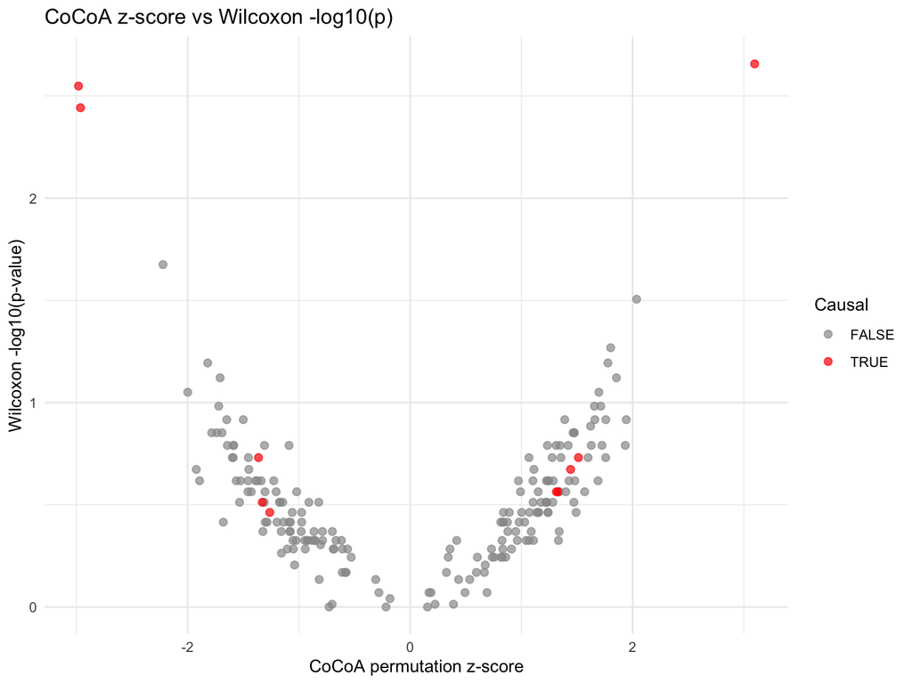

```r
comparison <- merge(
  cocoa_perm %>% select(gene, z_score, cocoa_pval = pvalue, causal),
  wilcox_results %>% select(gene, wilcox_pval = pvalue),
  by = "gene"
)

ggplot(comparison, aes(x = z_score, y = -log10(wilcox_pval), color = causal)) +
  geom_point(alpha = 0.7, size = 2) +
  scale_color_manual(values = c("FALSE" = "grey60", "TRUE" = "red")) +
  theme_minimal() +
  labs(
    title = "CoCoA z-score vs Wilcoxon -log10(p)",
    x = "CoCoA permutation z-score",
    y = "Wilcoxon -log10(p-value)",
    color = "Causal"
  )
```

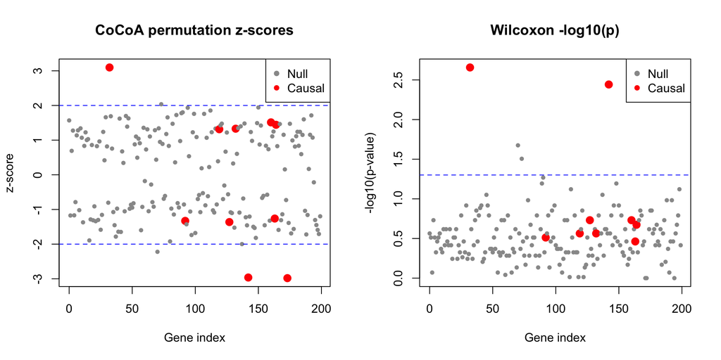

```r
par(mfrow = c(1, 2))

# CoCoA
plot(as.numeric(cocoa_perm$gene), cocoa_perm$z_score,
     pch = 16, col = ifelse(cocoa_perm$causal, "red", "grey60"),
     cex = ifelse(cocoa_perm$causal, 1.5, 0.8),
     xlab = "Gene index", ylab = "z-score",
     main = "CoCoA permutation z-scores")
abline(h = c(-2, 2), lty = 2, col = "blue")
legend("topright", legend = c("Null", "Causal"),
       pch = 16, col = c("grey60", "red"))

# Wilcoxon
plot(as.numeric(wilcox_results$gene), -log10(wilcox_results$pvalue),
     pch = 16, col = ifelse(wilcox_results$causal, "red", "grey60"),
     cex = ifelse(wilcox_results$causal, 1.5, 0.8),
     xlab = "Gene index", ylab = "-log10(p-value)",
     main = "Wilcoxon -log10(p)")
abline(h = -log10(0.05), lty = 2, col = "blue")
legend("topright", legend = c("Null", "Causal"),
       pch = 16, col = c("grey60", "red"))
```

```r
par(mfrow = c(1, 1))
```

### True Positive / False Positive Table

```r
thresholds <- c(0.001, 0.01, 0.05, 0.1)

cocoa_table <- sapply(thresholds, function(alpha) {
  sig <- comparison$cocoa_pval < alpha
  c(TP = sum(sig & comparison$causal),
    FP = sum(sig & !comparison$causal),
    FN = sum(!sig & comparison$causal),
    TN = sum(!sig & !comparison$causal))
})
colnames(cocoa_table) <- paste0("alpha=", thresholds)

wilcox_table <- sapply(thresholds, function(alpha) {
  sig <- comparison$wilcox_pval < alpha
  c(TP = sum(sig & comparison$causal),
    FP = sum(sig & !comparison$causal),
    FN = sum(!sig & comparison$causal),
    TN = sum(!sig & !comparison$causal))
})
colnames(wilcox_table) <- paste0("alpha=", thresholds)

cat("=== CoCoA (permutation) ===\n")
```

```
## === CoCoA (permutation) ===
```

```r
print(cocoa_table)
```

```
##    alpha=0.001 alpha=0.01 alpha=0.05 alpha=0.1
## TP           0          3          3         3
## FP           0          0          3        26
## FN          10          7          7         7
## TN         190        190        187       164
```

```r
cat("\n=== Wilcoxon rank-sum ===\n")
```

```
##
## === Wilcoxon rank-sum ===
```

```r
print(wilcox_table)
```

```
##    alpha=0.001 alpha=0.01 alpha=0.05 alpha=0.1
## TP           0          3          3         3
## FP           0          0          2         9
## FN          10          7          7         7
## TN         190        190        188       181
```